# CHARACTERS STATS

## 1. Import required library

```python
import pandas as pd
import matplotlib.pyplot as plt
```

## 2. Read CSV

```python
df = pd.read_csv('characters_stats.csv')
df
```

|  | Name | Alignment | Intelligence | Strength | Speed | Durability | Power | Combat | Total |
| --- | --- | --- | --- | --- | --- | --- | --- | --- | --- |
| 0 | 3-D Man | good | 50 | 31 | 43 | 32 | 25 | 52 | 233 |
| 1 | A-Bomb | good | 38 | 100 | 17 | 80 | 17 | 64 | 316 |
| 2 | Abe Sapien | good | 88 | 14 | 35 | 42 | 35 | 85 | 299 |
| 3 | Abin Sur | good | 50 | 90 | 53 | 64 | 84 | 65 | 406 |
| 4 | Abomination | bad | 63 | 80 | 53 | 90 | 55 | 95 | 436 |
| ... | ... | ... | ... | ... | ... | ... | ... | ... | ... |
| 606 | Yellowjacket | good | 88 | 10 | 12 | 28 | 12 | 14 | 164 |
| 607 | Yellowjacket II | good | 50 | 10 | 35 | 28 | 31 | 28 | 182 |
| 608 | Ymir | good | 50 | 100 | 27 | 100 | 83 | 28 | 388 |
| 609 | Zatanna | good | 75 | 10 | 23 | 28 | 100 | 56 | 292 |
| 610 | Zoom | bad | 50 | 10 | 100 | 28 | 72 | 28 | 288 |

611 rows × 9 columns

## 3. Show first records from csv

```python
df.head()
```

|  | Name | Alignment | Intelligence | Strength | Speed | Durability | Power | Combat | Total |
| --- | --- | --- | --- | --- | --- | --- | --- | --- | --- |
| 0 | 3-D Man | good | 50 | 31 | 43 | 32 | 25 | 52 | 233 |
| 1 | A-Bomb | good | 38 | 100 | 17 | 80 | 17 | 64 | 316 |
| 2 | Abe Sapien | good | 88 | 14 | 35 | 42 | 35 | 85 | 299 |
| 3 | Abin Sur | good | 50 | 90 | 53 | 64 | 84 | 65 | 406 |
| 4 | Abomination | bad | 63 | 80 | 53 | 90 | 55 | 95 | 436 |

## 4. Show number of rows and columns

### Option 1: use info()

```python
df.info()
```

```
<class 'pandas.core.frame.DataFrame'>
RangeIndex: 611 entries, 0 to 610
Data columns (total 9 columns):
 #   Column        Non-Null Count  Dtype
---  ------        --------------  -----
 0   Name          611 non-null    object
 1   Alignment     608 non-null    object
 2   Intelligence  611 non-null    int64
 3   Strength      611 non-null    int64
 4   Speed         611 non-null    int64
 5   Durability    611 non-null    int64
 6   Power         611 non-null    int64
 7   Combat        611 non-null    int64
 8   Total         611 non-null    int64
dtypes: int64(7), object(2)
memory usage: 43.1+ KB
```

### Option 2: use len()

```python
print("Number of columns: ", len(df.columns))
print("Number of rows: ", len(df))
```

```
Number of columns:  9
Number of rows:  611
```

### Use size will return the total number of cells in the df

```python
df.size    #columns=9, rows=611 --> size=9*611
```

```
5499
```

## 5. You need to find the values of alignment, can use value_counts()

### Correct answer: Use value_counts() to show the unique values ad their number of occurance

```python
df['Alignment'].value_counts()
```

```
good       432
bad        165
neutral     11
Name: Alignment, dtype: int64
```

### Use nunique() will only show number of unique values

```python
df['Alignment'].nunique()
```

```
3
```

### Use count() to count non-null values, use size to count values including nulls

```python
print(df['Alignment'].count())   #count non-null values
print(df['Alignment'].size)      #count all values
```

```
608
611
```

### Use pd.agg() (new in pandas 0.20.0)

```python
df.agg(['count','size','nunique'])
```

|  | Name | Alignment | Intelligence | Strength | Speed | Durability | Power | Combat | Total |
| --- | --- | --- | --- | --- | --- | --- | --- | --- | --- |
| count | 611 | 608 | 611 | 611 | 611 | 611 | 611 | 611 | 611 |
| size | 611 | 611 | 611 | 611 | 611 | 611 | 611 | 611 | 611 |
| nunique | 610 | 3 | 19 | 57 | 42 | 42 | 93 | 38 | 262 |

## 6. Find out only good alignment holders superheroes

```python
df1 = df.loc[df['Alignment']=='good']
df1
```

|  | Name | Alignment | Intelligence | Strength | Speed | Durability | Power | Combat | Total |
| --- | --- | --- | --- | --- | --- | --- | --- | --- | --- |
| 0 | 3-D Man | good | 50 | 31 | 43 | 32 | 25 | 52 | 233 |
| 1 | A-Bomb | good | 38 | 100 | 17 | 80 | 17 | 64 | 316 |
| 2 | Abe Sapien | good | 88 | 14 | 35 | 42 | 35 | 85 | 299 |
| 3 | Abin Sur | good | 50 | 90 | 53 | 64 | 84 | 65 | 406 |
| 6 | Adam Monroe | good | 63 | 10 | 12 | 100 | 71 | 64 | 320 |
| ... | ... | ... | ... | ... | ... | ... | ... | ... | ... |
| 604 | X-Man | good | 88 | 53 | 53 | 95 | 92 | 84 | 465 |
| 606 | Yellowjacket | good | 88 | 10 | 12 | 28 | 12 | 14 | 164 |
| 607 | Yellowjacket II | good | 50 | 10 | 35 | 28 | 31 | 28 | 182 |
| 608 | Ymir | good | 50 | 100 | 27 | 100 | 83 | 28 | 388 |
| 609 | Zatanna | good | 75 | 10 | 23 | 28 | 100 | 56 | 292 |

432 rows × 9 columns

```python
df1.head(6)
```

|  | Name | Alignment | Intelligence | Strength | Speed | Durability | Power | Combat | Total |
| --- | --- | --- | --- | --- | --- | --- | --- | --- | --- |
| 0 | 3-D Man | good | 50 | 31 | 43 | 32 | 25 | 52 | 233 |
| 1 | A-Bomb | good | 38 | 100 | 17 | 80 | 17 | 64 | 316 |
| 2 | Abe Sapien | good | 88 | 14 | 35 | 42 | 35 | 85 | 299 |
| 3 | Abin Sur | good | 50 | 90 | 53 | 64 | 84 | 65 | 406 |
| 6 | Adam Monroe | good | 63 | 10 | 12 | 100 | 71 | 64 | 320 |
| 7 | Adam Strange | good | 1 | 1 | 1 | 1 | 0 | 1 | 5 |

## 8. Show top five records having top speed of heroes of good alignment

```python
df1.sort_values(by='Speed', ascending=False).head(5)
```

|  | Name | Alignment | Intelligence | Strength | Speed | Durability | Power | Combat | Total |
| --- | --- | --- | --- | --- | --- | --- | --- | --- | --- |
| 231 | Flash III | good | 63 | 10 | 100 | 60 | 83 | 32 | 348 |
| 304 | Jack of Hearts | good | 63 | 55 | 100 | 30 | 70 | 30 | 348 |
| 295 | Impulse | good | 50 | 10 | 100 | 60 | 63 | 60 | 343 |
| 525 | Stardust | good | 88 | 85 | 100 | 110 | 100 | 85 | 568 |
| 447 | Quicksilver | good | 63 | 28 | 100 | 60 | 57 | 56 | 364 |

## 9. Show 5 records of super heroes who have maximum power of good alignment

```python
df1.sort_values(by='Power', ascending=False).head(5)
```

|  | Name | Alignment | Intelligence | Strength | Speed | Durability | Power | Combat | Total |
| --- | --- | --- | --- | --- | --- | --- | --- | --- | --- |
| 609 | Zatanna | good | 75 | 10 | 23 | 28 | 100 | 56 | 292 |
| 546 | Thor | good | 69 | 100 | 92 | 100 | 100 | 85 | 546 |
| 511 | Spawn | good | 75 | 60 | 50 | 90 | 100 | 95 | 470 |
| 69 | Beta Ray Bill | good | 63 | 80 | 35 | 95 | 100 | 84 | 457 |
| 70 | Beyonder | good | 88 | 100 | 23 | 100 | 100 | 56 | 467 |

## 10. Find out how many super heroes are there with power 100 of good alignment

### Option 1: Use count()

```python
df1.loc[df['Power']==100].count()
#Attention: Here we use 100 as integer, not string, as integer is the data type for the Power column
#If we use '100' instead of 100, it'll throw an error
```

```
Name            33
Alignment       33
Intelligence    33
Strength        33
Speed           33
Durability      33
Power           33
Combat          33
Total           33
dtype: int64
```

### Option 2: Use len()

```python
len(df1.loc[df1['Power']==100])
```

```
33
```

## 11. Shape them what you got in point 10

```python
#I don't understand this question....
```

## 12. Show all records from point 10

```python
pd.set_option('display.max_columns', None)
df1.loc[df['Power']==100]
```

|  | Name | Alignment | Intelligence | Strength | Speed | Durability | Power | Combat | Total |
| --- | --- | --- | --- | --- | --- | --- | --- | --- | --- |
| 69 | Beta Ray Bill | good | 63 | 80 | 35 | 95 | 100 | 84 | 457 |
| 70 | Beyonder | good | 88 | 100 | 23 | 100 | 100 | 56 | 467 |
| 85 | Black Bolt | good | 75 | 67 | 100 | 84 | 100 | 56 | 482 |
| 129 | Cable | good | 88 | 48 | 23 | 56 | 100 | 80 | 395 |
| 185 | Deadman | good | 50 | 10 | 33 | 100 | 100 | 42 | 335 |
| 196 | Doctor Fate | good | 81 | 16 | 25 | 80 | 100 | 50 | 352 |
| 198 | Doctor Strange | good | 100 | 10 | 12 | 84 | 100 | 60 | 366 |
| 204 | Dr Manhattan | good | 88 | 32 | 42 | 95 | 100 | 42 | 399 |
| 226 | Firestorm | good | 50 | 53 | 58 | 56 | 100 | 42 | 359 |
| 251 | Goku | good | 56 | 100 | 75 | 90 | 100 | 100 | 521 |
| 266 | Hal Jordan | good | 63 | 90 | 53 | 64 | 100 | 56 | 426 |
| 294 | Iceman | good | 63 | 32 | 53 | 100 | 100 | 64 | 412 |
| 299 | Iron Man | good | 100 | 85 | 58 | 85 | 100 | 64 | 492 |
| 306 | Jean Grey | good | 100 | 80 | 67 | 100 | 100 | 70 | 517 |
| 327 | Kilowog | good | 81 | 90 | 53 | 42 | 100 | 80 | 446 |
| 361 | Martian Manhunter | good | 100 | 100 | 96 | 100 | 100 | 85 | 581 |
| 362 | Marvel Girl | good | 63 | 85 | 47 | 42 | 100 | 80 | 417 |
| 383 | Miss Martian | good | 63 | 85 | 58 | 100 | 100 | 45 | 451 |
| 408 | Naruto Uzumaki | good | 50 | 80 | 32 | 80 | 100 | 100 | 442 |
| 417 | Nova | good | 100 | 85 | 67 | 101 | 100 | 85 | 538 |
| 418 | Nova | good | 38 | 60 | 100 | 100 | 100 | 25 | 423 |
| 419 | Offspring | good | 50 | 10 | 35 | 99 | 100 | 56 | 350 |
| 433 | Phoenix | good | 100 | 80 | 67 | 100 | 100 | 70 | 517 |
| 435 | Plastic Man | good | 50 | 63 | 23 | 100 | 100 | 56 | 392 |
| 487 | Shadow King | good | 75 | 12 | 27 | 100 | 100 | 75 | 389 |
| 499 | Silver Surfer | good | 63 | 100 | 84 | 101 | 100 | 32 | 480 |
| 511 | Spawn | good | 75 | 60 | 50 | 90 | 100 | 95 | 470 |
| 525 | Stardust | good | 88 | 85 | 100 | 110 | 100 | 85 | 568 |
| 546 | Thor | good | 69 | 100 | 92 | 100 | 100 | 85 | 546 |
| 547 | Thor Girl | good | 75 | 83 | 70 | 84 | 100 | 70 | 482 |
| 583 | War Machine | good | 63 | 80 | 63 | 100 | 100 | 85 | 491 |
| 589 | Watcher | good | 100 | 80 | 67 | 89 | 100 | 56 | 492 |
| 609 | Zatanna | good | 75 | 10 | 23 | 28 | 100 | 56 | 292 |

## 13. Retrieve total of first five records of max power of good alignment super heroes

```python
df2 = df1.sort_values(by='Power', ascending=False).head(5)
df2
```

|  | Name | Alignment | Intelligence | Strength | Speed | Durability | Power | Combat | Total |
| --- | --- | --- | --- | --- | --- | --- | --- | --- | --- |
| 609 | Zatanna | good | 75 | 10 | 23 | 28 | 100 | 56 | 292 |
| 546 | Thor | good | 69 | 100 | 92 | 100 | 100 | 85 | 546 |
| 511 | Spawn | good | 75 | 60 | 50 | 90 | 100 | 95 | 470 |
| 69 | Beta Ray Bill | good | 63 | 80 | 35 | 95 | 100 | 84 | 457 |
| 70 | Beyonder | good | 88 | 100 | 23 | 100 | 100 | 56 | 467 |

## 14. Draw a bar plot of all super heroes who are having good alignment and max power of top five only, take same object of point 13, show name and total in plot with green bars

### Use matplotlib.pyplot

[figure not shown]

```python
plt.bar(df2['Name'],df2['Total'], color='green')
plt.title("Top 5 heroes with highest power", fontweight='bold')
plt.xlabel("Name", color='green')
plt.ylabel("Power", color='green')

for x,y in zip(df2['Name'],df2['Total']):
    label=y
    plt.annotate(label, (x,y), xytext=(0,3), textcoords='offset pixels', ha='center')

#See more info about annotation here: https://matplotlib.org/stable/api/_as_gen/matplotlib.pyplot.annotate.html?highlight=annotate#matplotlib.pyplot.annotate

fig1 = plt.gcf()     #gcf is 'get current figure'
```

### Option 2: Use pandas

[figure not shown]

[figure not shown]

```python
#We can specify x and y:
df2.plot(x='Name', y= 'Total', kind='bar')

#Or we can just specify x:
df2.plot(x='Name', kind='bar')
```

## 15. Extract villains having bad alignment

```python
df3 = df.loc[df['Alignment']=='bad']
df3
```

|  | Name | Alignment | Intelligence | Strength | Speed | Durability | Power | Combat | Total |
| --- | --- | --- | --- | --- | --- | --- | --- | --- | --- |
| 4 | Abomination | bad | 63 | 80 | 53 | 90 | 55 | 95 | 436 |
| 5 | Abraxas | bad | 88 | 100 | 83 | 99 | 100 | 56 | 526 |
| 11 | Air-Walker | bad | 50 | 85 | 100 | 85 | 100 | 40 | 460 |
| 16 | Amazo | bad | 75 | 100 | 100 | 100 | 100 | 100 | 575 |
| 17 | Ammo | bad | 1 | 1 | 1 | 1 | 0 | 1 | 5 |
| ... | ... | ... | ... | ... | ... | ... | ... | ... | ... |
| 586 | Warp | bad | 38 | 10 | 23 | 28 | 63 | 50 | 212 |
| 590 | Weapon XI | bad | 1 | 1 | 1 | 1 | 0 | 1 | 5 |
| 593 | Willis Stryker | bad | 38 | 16 | 23 | 28 | 41 | 60 | 206 |
| 605 | Yellow Claw | bad | 1 | 1 | 1 | 1 | 0 | 1 | 5 |
| 610 | Zoom | bad | 50 | 10 | 100 | 28 | 72 | 28 | 288 |

165 rows × 9 columns

## 16. Show first five records of point 15

```python
df3.head(5)
```

|  | Name | Alignment | Intelligence | Strength | Speed | Durability | Power | Combat | Total |
| --- | --- | --- | --- | --- | --- | --- | --- | --- | --- |
| 4 | Abomination | bad | 63 | 80 | 53 | 90 | 55 | 95 | 436 |
| 5 | Abraxas | bad | 88 | 100 | 83 | 99 | 100 | 56 | 526 |
| 11 | Air-Walker | bad | 50 | 85 | 100 | 85 | 100 | 40 | 460 |
| 16 | Amazo | bad | 75 | 100 | 100 | 100 | 100 | 100 | 575 |
| 17 | Ammo | bad | 1 | 1 | 1 | 1 | 0 | 1 | 5 |

## 17. Show top five fastest super villains in terms of super speed

```python
df3.sort_values(by='Speed', ascending=False).head(5)
```

|  | Name | Alignment | Intelligence | Strength | Speed | Durability | Power | Combat | Total |
| --- | --- | --- | --- | --- | --- | --- | --- | --- | --- |
| 610 | Zoom | bad | 50 | 10 | 100 | 28 | 72 | 28 | 288 |
| 11 | Air-Walker | bad | 50 | 85 | 100 | 85 | 100 | 40 | 460 |
| 16 | Amazo | bad | 75 | 100 | 100 | 100 | 100 | 100 | 575 |
| 535 | Superboy-Prime | bad | 94 | 100 | 100 | 100 | 100 | 85 | 579 |
| 242 | General Zod | bad | 94 | 100 | 96 | 100 | 94 | 95 | 579 |

## 18. Top five super villains in terms of intelligence

```python
df3.sort_values(by='Intelligence', ascending=False).head(5)
```

|  | Name | Alignment | Intelligence | Strength | Speed | Durability | Power | Combat | Total |
| --- | --- | --- | --- | --- | --- | --- | --- | --- | --- |
| 386 | Mister Mxyzptlk | bad | 113 | 10 | 12 | 14 | 100 | 28 | 277 |
| 338 | Lex Luthor | bad | 100 | 10 | 12 | 14 | 10 | 28 | 174 |
| 336 | Leader | bad | 100 | 10 | 12 | 14 | 58 | 42 | 236 |
| 122 | Brainiac | bad | 100 | 28 | 63 | 90 | 60 | 75 | 416 |
| 194 | Doctor Doom | bad | 100 | 32 | 20 | 100 | 93 | 84 | 429 |

## 19. Show who is most dangerous super villain after calculating their total (top 5 only)

```python
df3.sort_values(by='Total', ascending=False).head(5)
```

|  | Name | Alignment | Intelligence | Strength | Speed | Durability | Power | Combat | Total |
| --- | --- | --- | --- | --- | --- | --- | --- | --- | --- |
| 535 | Superboy-Prime | bad | 94 | 100 | 100 | 100 | 100 | 85 | 579 |
| 242 | General Zod | bad | 94 | 100 | 96 | 100 | 94 | 95 | 579 |
| 16 | Amazo | bad | 75 | 100 | 100 | 100 | 100 | 100 | 575 |
| 203 | Dormammu | bad | 88 | 95 | 83 | 100 | 100 | 80 | 546 |
| 201 | Doomsday | bad | 88 | 80 | 67 | 120 | 100 | 90 | 545 |

## 20. Draw a histogram for speed of super heroes having fig size 10,5 , provide speed in histogram for only good alignment super heroes ,title should be "distribution of speed" , xlabel should be "speed"

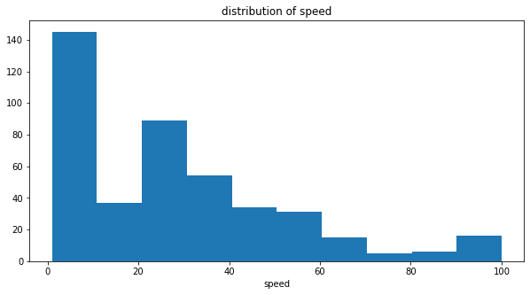

```python
plt.figure(figsize=(10,5))
plt.hist(x=df1['Speed'])
plt.title('distribution of speed')
plt.xlabel('speed')
```

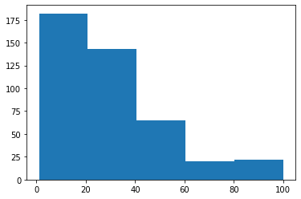

```python
#We can also use parameter 'bins' to define number of bins for our histogram
#The above plot has 10 bins
#Now we decrease it to 5 bins:
plt.hist(x=df1['Speed'], bins=5)
```

## 21. Draw a histogram for combat of super villains having fig size 10,5 , provide combat in histogram for only bad alignment super heroes ,title should be "distribution of combat" , xlabel should be "combat"

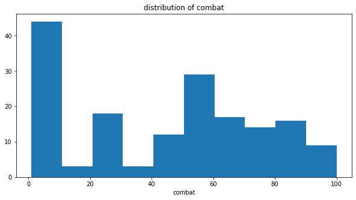

```python
plt.figure(figsize=(10,5))
plt.hist(x=df3['Combat'])
plt.title('distribution of combat')
plt.xlabel('combat')
```